# Suicidio-Brasil

## ANALISE DE DADOS SETEMBRO AMARELO

Nome: Clauder Noronha

Data: Setembro de 2017

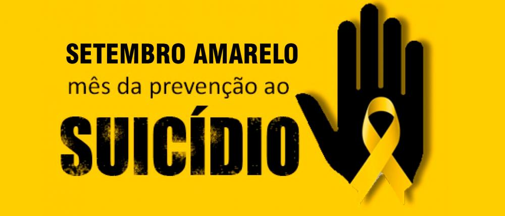

Todo suicídio é uma tragédia e sua causa um mistério. Suicídio é resultado de um profundo sentimento de desesperança e a inabilidade de ver soluções para problemas ou lidar com circunstâncias desafiadoras da vida. Potencial suicidas, podem se ver tirando a própria vida como a única solução possível.

Estatisticamente, o suicídio ocorre com maior frequência entre pessoas de 45 a 54 anos. As mulheres são mais propensas que os homens a tentarem suicídio; os homens são mais propensos que as mulheres a concluir o ato. O suicídio é uma questão de saúde pública, que leva 32 brasileiros por dia, mais do que o HIV ou muitos tipos de câncer, por exemplo. Assim, se o suicídio é prevenível em 90% dos casos, como aponta a Organização Mundial da Saúde, é preciso saber como preveni-lo e isso só se sabe com informação e conhecimento.

Fonte:https://exame.com/negocios/dino_old/no-brasil-ao-contrario-do-mundo-o-suicidio-cresce-estrondosamente/

```python
#import pacotes

import pandas as pd
import numpy as np
import matplotlib.pyplot as plt
%matplotlib inline
import seaborn as sns

import plotly.offline as py
import plotly.graph_objs as go
py.init_notebook_mode(connected=True)
```

```python
dados = pd.read_csv('suicide_rates.csv')
```

```python
#Vamos conhecer a base de dados
dados.head()
```

|  | country | year | sex | age | suicides_no | population | suicides/100k pop | country-year | HDI for year | gdp_for_year ($) | gdp_per_capita ($) | generation |
| --- | --- | --- | --- | --- | --- | --- | --- | --- | --- | --- | --- | --- |
| 0 | Albania | 1987 | male | 15-24 years | 21 | 312900 | 6.71 | Albania1987 | NaN | 2,156,624,900 | 796 | Generation X |
| 1 | Albania | 1987 | male | 35-54 years | 16 | 308000 | 5.19 | Albania1987 | NaN | 2,156,624,900 | 796 | Silent |
| 2 | Albania | 1987 | female | 15-24 years | 14 | 289700 | 4.83 | Albania1987 | NaN | 2,156,624,900 | 796 | Generation X |
| 3 | Albania | 1987 | male | 75+ years | 1 | 21800 | 4.59 | Albania1987 | NaN | 2,156,624,900 | 796 | G.I. Generation |
| 4 | Albania | 1987 | male | 25-34 years | 9 | 274300 | 3.28 | Albania1987 | NaN | 2,156,624,900 | 796 | Boomers |

### Dicionario

Esse arquivo csv possui 12 colunas. São elas:

country: país onde os dados foram registrados

- 101 países

year: ano em que os dados foram registrados

sex: sexo considerado no registro

- male - masculino
- female - feminino

age: faixa etária considerada

- 5-14 anos
- 15-24 anos
- 25-34 anos
- 35-54 anos
- 55-74 anos
- 75+ anos

suicides_no: número de suicídios

population: população para o grupo

suicides/100k pop: número de suicídios por 100 mil habitantes

country_year: identificador contendo country + year

HDI for year: Índice de Desenvolvimento Humano (IDH) para o ano

gdp_for_year: Produto Interno Bruto (PIB) para o ano

gdp_per_capita: Produto Interno Bruto (PIB) per capita

Analise dos Dados

O Conjunto de dados contém 27.820 linhas e 12 colunas. Os dados são agrupados por vários critérios como país, ano, sexo e idade.

```python
print('Formato do Dataframe:', dados.shape)
```

```
Formato do Dataframe: (27820, 12)
```

O estudo de caso vai ser apenas os casos ocorrido no Brasil.

A base de dados foi reduzida para 372 linhas e 12 colunas. Usei o comando head para mostrar as 5 primeiras linhas.

```python
dados_Brasil = dados[dados.country == 'Brazil'].copy()

#formato do Dataframe
print('o formato é:', dados_Brasil.shape)

dados_Brasil.head(5)
```

```
o formato é: (372, 12)
```

|  | country | year | sex | age | suicides_no | population | suicides/100k pop | country-year | HDI for year | gdp_for_year ($) | gdp_per_capita ($) | generation |
| --- | --- | --- | --- | --- | --- | --- | --- | --- | --- | --- | --- | --- |
| 4172 | Brazil | 1985 | male | 75+ years | 129 | 840300 | 15.35 | Brazil1985 | 0.576 | 222,942,790,435 | 1898 | G.I. Generation |
| 4173 | Brazil | 1985 | male | 55-74 years | 535 | 5364900 | 9.97 | Brazil1985 | 0.576 | 222,942,790,435 | 1898 | G.I. Generation |
| 4174 | Brazil | 1985 | male | 35-54 years | 1011 | 11986300 | 8.43 | Brazil1985 | 0.576 | 222,942,790,435 | 1898 | Silent |
| 4175 | Brazil | 1985 | male | 25-34 years | 791 | 10762900 | 7.35 | Brazil1985 | 0.576 | 222,942,790,435 | 1898 | Boomers |
| 4176 | Brazil | 1985 | male | 15-24 years | 661 | 13834000 | 4.78 | Brazil1985 | 0.576 | 222,942,790,435 | 1898 | Generation X |

Vamos descobrir com o comando Info o formato das nossas variáveis.

```python
dados_Brasil.info()
```

```
<class 'pandas.core.frame.DataFrame'>
Int64Index: 372 entries, 4172 to 4543
Data columns (total 12 columns):
 #   Column              Non-Null Count  Dtype
---  ------              --------------  -----
 0   country             372 non-null    object
 1   year                372 non-null    int64
 2   sex                 372 non-null    object
 3   age                 372 non-null    object
 4   suicides_no         372 non-null    int64
 5   population          372 non-null    int64
 6   suicides/100k pop   372 non-null    float64
 7   country-year        372 non-null    object
 8   HDI for year        120 non-null    float64
 9    gdp_for_year ($)   372 non-null    object
 10  gdp_per_capita ($)  372 non-null    int64
 11  generation          372 non-null    object
dtypes: float64(2), int64(4), object(6)
memory usage: 37.8+ KB
```

Para ter uma noção da integridade dos dados, vou verificar isoladamente os DataFrames do Brasil e o Mundial. Principalmente quando se quer comparar duas coisas, é importante que eles sejam similares e estatisticamente representativas.

Como você vê abaixo, a porcentagem de valores ausentes referentes ao IDH torna inviável o uso dessa variável. Caso se desejasse realmente usar, seria necessária uma etapa de coleta de dados a partir de outras fontes.

```python
# Valores ausentes base mundo:
print("-->Mundo:")
display(dados.isnull().sum())

print("\n", "--.--"*10,"\n")


#Valores ausente base Brasil

print("---> Brasil")

display(dados_Brasil.isnull().sum())

print("\n", "--.--"*10,"\n")
```

```
-->Mundo:
```

```
country                   0
year                      0
sex                       0
age                       0
suicides_no               0
population                0
suicides/100k pop         0
country-year              0
HDI for year          19456
 gdp_for_year ($)         0
gdp_per_capita ($)        0
generation                0
dtype: int64
```

```
 --.----.----.----.----.----.----.----.----.----.--

---> Brasil
```

```
country                 0
year                    0
sex                     0
age                     0
suicides_no             0
population              0
suicides/100k pop       0
country-year            0
HDI for year          252
 gdp_for_year ($)       0
gdp_per_capita ($)      0
generation              0
dtype: int64
```

```
 --.----.----.----.----.----.----.----.----.----.--
```

### Tendência da taxa de suicídio no Brasil

Uma primeira comparação que farei diz respeito ao número de suicídios cometidos no Brasil por 100 mil habitantes, e a tendência do gráfico em relação à taxa mundial.

Para ver a tendência, é melhor sempre usar essa relação por 100 mil, pois a população do país cresceu muito de 1985 para 2015. Se formos comparar em termos absolutos, poderemos tirar conclusões erradas ou distorcidas.

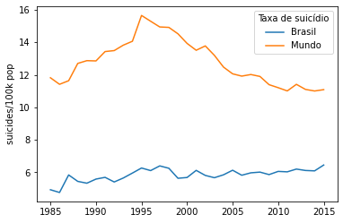

```python
# pegar a media mundial e do Brasil em suicidios
years = dados_Brasil.year.unique()    # pegar os anos para o eixo x
suicides_brasil_mean = dados_Brasil.groupby('year')['suicides/100k pop'].mean()
suicides_world_mean = dados.groupby('year')['suicides/100k pop'].mean()

# como o Brasil nao tem 2016, vou eliminar do dataframe mundial essa entrada
suicides_world_mean.drop(2016, inplace=True)

# plotar lineplot comparativo entre Brasil e Mundo
ax = sns.lineplot(x=years, y=suicides_brasil_mean, label='Brasil')
ax = sns.lineplot(x=years, y=suicides_world_mean, label='Mundo')
plt.legend(title="Taxa de suicídio")
plt.show()
```

Uma coisa que é facilmente percebida no gráfico acima é que apesar da taxa de suicídios no Brasil ser menor que a média mundial, ela vem crescendo constantemente ao longo de 30 anos.

A linha laranja teve um pico por volta de 1995, porém reverteu o slope e vem caindo ano após ano. Já a linha azul (Brasil) tem um slope positivo praticamente ao longo de todo o período analisado.

### Vamos analizar o ano com mais suícidio

```python
Ano_Brasil = dados_Brasil.groupby('year')['suicides_no'].sum()


Ano_Brasil
```

```
year
1985     4228
1986     4271
1987     4672
1988     4466
1989     4463
1990     4803
1991     5156
1992     5207
1993     5508
1994     5896
1995     6536
1996     6698
1997     6891
1998     6922
```

[output cut: 18 more lines]

### Plotar um Gráfico para mostrar a quantidade de mortes durante os anos.

```python
trace = go.Scatter(x = dados_Brasil['year'],
                   y = dados_Brasil['suicides_no'],
                   mode = 'markers')
data = [trace]
py.iplot (data)
```

[interactive chart not shown]

### Faixa etária com maior índice de suícidio

Meu principal objetivo aqui é identificar qual a faixa etária que tem a maior representatividade entre aqueles que tiram a própria vida, e identificar se houve alguma mudança no perfil ao longo de 30 anos.

```python
# criar uma tabela dinâmica
table = pd.pivot_table(dados_Brasil, values='suicides_no', index=['year'], columns=['age'])

# reordenar as tableas para deixar em ordem crescente
column_order = ['5-14 years', '15-24 years', '25-34 years', '35-54 years', '55-74 years', '75+ years']
table = table.reindex(column_order, axis=1)

# ver as 5 primeiras entradas da pivot table
table.head()
```

| age year | 5-14 years | 15-24 years | 25-34 years | 35-54 years | 55-74 years | 75+ years |
| --- | --- | --- | --- | --- | --- | --- |
| 1985 | 38.0 | 470.5 | 530.0 | 653.5 | 341.5 | 80.5 |
| 1986 | 31.0 | 508.0 | 505.5 | 651.0 | 372.0 | 68.0 |
| 1987 | 33.5 | 502.0 | 565.5 | 724.5 | 422.0 | 88.5 |
| 1988 | 30.0 | 472.0 | 557.5 | 724.0 | 356.0 | 93.5 |
| 1989 | 31.5 | 491.5 | 569.0 | 692.5 | 354.5 | 92.5 |

### Plotar a pivot table das faixas etárias

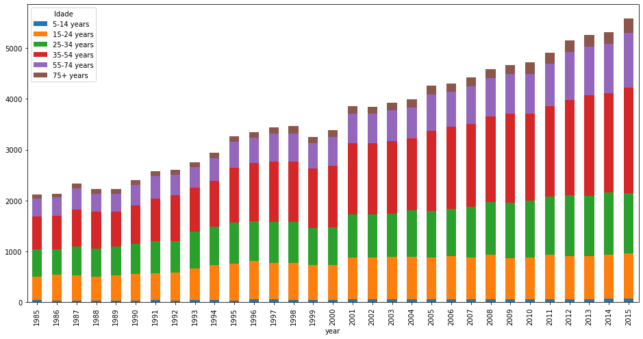

```python
table.plot.bar(stacked=True, figsize=(16,8))
plt.legend(title='Idade')
plt.show()
```

Mesmo visualmete é fácil identificar que o grupo de pessoas que mais cometem suicídio está entre 35-54 anos. Em segundo lugar, estão pessoas entre 25-34 anos.

Juntos, esses dois grupos correspondem a quase 60% dos registros do banco de dados.

```python
#Estatistica de suicídios por faixa etária.

table[['25-34 years']].loc[2015]
table.loc[2015] / table.loc[2015].sum()
```

```
age
5-14 years     0.012094
15-24 years    0.159993
25-34 years    0.211681
35-54 years    0.371585
55-74 years    0.194571
75+ years      0.050076
Name: 2015, dtype: float64
```

Um outro ponto que vale a pena ressaltar é o aumento de casos entre pessoas acima de 55 anos. Em 1985, as pessoas com mais idade representavam uma pequena fatia do número total.

Entretanto, em 2015 é nítido que mesmo para pessoas acima de 75 anos houve um incremento significativo no número de suicídios.

Para se inferir a causa dessa mudança de padrão, é necessário se avaliar mais profundamente questões que vão além dos números (como exemplo, fatores qualitativos, momento econômico do país e a cultura dominante de cada época).

### Taxa de suicídio entre homens e mulheres

Uma outra análise de grande importância é ver a porcentagem dos suicídios entre homens e mulheres.

Analisando-se todo o período, o dataset utilizado mostrou que aproximadamente 78% dos casos foram cometidos por homens e 22% deles por mulheres. Optou-se por pegar a média dos 30 anos, pois não houve mudança significativa desse comportamento durante o período.

```python
#Extrair valores entre homens e mulheres

homem_mulher = dados_Brasil.groupby('sex').suicides_no.sum()/ dados_Brasil.groupby('sex').suicides_no.sum().sum()
```

### Criar um grafico entre homens e mulheres

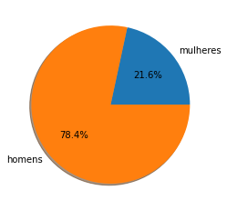

```python
plt.pie(homem_mulher, labels=['mulheres','homens'], autopct='%1.1f%%', shadow=True)

plt.show()
```

### Correlações entre o PIB, IDH e número de suicídios

Em relação ao IDH, como foi mencionado anteriormente, há muitos valores ausentes nas células, o que pode dar uma interpretação incorreta ou com viés.

```python
#Criar um mapa de calor
```

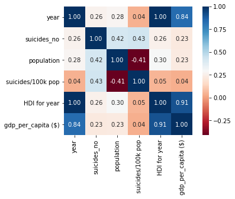

```python
corr = dados_Brasil.corr()
sns.heatmap(corr, cmap='RdBu', fmt='.2f', square=True, linecolor='white', annot=True);
```

### Data Science na prevenção do suicídio

O que eu quis trazer neste artigo foi um projeto de análise de dados visando conscientizar a comunidade Python e Data Science sobre a real importância de um problema tão latente nos dias atuais - porém negligenciado ou ignorado por boa parte das pessoas.

O conjunto de dados usado aqui é simplificado, porém ideal para uma abordagem inicial, para se criar uma consciência situacional a respeito do tema.

Há diversas iniciativas dentro do campo da Inteligência Artificial visando não apenas a conscientização, mas também prevenção de suicídios. Uma das mais populares diz respeito à análise de postagens em redes sociais, onde algoritmos de Machine Learning são capazes de identificar potenciais suicidas e alertar outras pessoas.

> A campanha é em setembro, mas falar sobre prevenção do suicídio em todos os meses do ano é fundamental -Setembro Amarelo

Ainda são iniciativas muito incipientes, que esbarram em muitas questões de privacidade, porém empresas como o Facebook já tem apostado nesse caminho.

Casos em que a pessoa parece estar decidida em tirar a vida, é primordial que ela não seja deixada sozinha. Podem ser contatados os serviços de saúde mental, familiares e amigos. Pode ser necessário que ela fique em um ambiente seguro, sendo auxiliada por um profissional. Se você perceber que a pessoa não se sente à vontade para se abrir, deixe claro que você estará disponível para conversar em outras oportunidades.

Você também pode indicar os serviços oferecidos pelo CVV, O Centro de Valorização da Vida disponível em http://www.cvv.org.br, que trabalha para promover o bem-estar das pessoas e prevenir o suicídio, em total sigilo, 24h por dia.

Precisamos nos informar e reconhecer os sinais, diferenciar mitos e verdades, ouvir profissionais e ter acesso a formas de apoio, como o próprio CVV.

Lembre-se que não é frescura e que ninguém está querendo aparecer. Na verdade, a gente nunca tem a mínima ideia do que a outra pessoa está passando. Qualquer atitude que você tenha que possa contribuir para a prevenção do suicídio, pode significar uma vida a mais ;)